# Assignment 4

## Used Libraries

```r
# This line of code will install all the necessary packages required for the code to run properly and efficiently.

# install.packages(c("abind", "forcats", "ggplot2", "ggradar", "ggrepel", "ggridges", "hrbrthemes", "lubridate", "plotly", "plyr", "purrr", "RColorBrewer", "readr", "scales", "stringr", "tibble", "tidyr", "tidyselect", "tidyverse", "viridis", "viridisLite"))

library(abind) # is used for combining arrays along multiple dimensions.
library(forcats) # is a package for working with categorical variables in R.
library(ggplot2) # is a popular data visualization package for creating complex plots and graphics.
library(ggradar) # is a package for creating radar charts.
library(ggrepel)# is used for avoiding label overlapping in ggplot2.
library(ggridges)# is used for creating ridgeline plots.
library(hrbrthemes) # is a package that provides several themes for ggplot2.
library(lubridate)# s used for working with dates and times in R.
library(plotly) # is a package for creating interactive plots and graphics.
library(plyr) # is a package for splitting, applying, and combining data.
library(purrr) #  is a package for functional programming in R.
library(RColorBrewer) #  is used for creating beautiful and distinct color palettes for maps and plots.
library(readr) #  is used for reading and writing tabular data in R.
library(scales) #  is used for working with scales and color palettes in ggplot2.
library(stringr) # is used for working with strings in R.
library(tibble) # is a package for creating tibbles, a modern re-imagining of data frames.
library(tidyr) # is used for reshaping data in R.
library(tidyselect) # is used for selecting columns of a data frame by name.
library(tidyverse) # is a collection of packages, including ggplot2, dplyr, tidyr, readr, purrr, and tibble, that are designed to work together for data manipulation and visualization.
# viridis and viridisLite are packages for creating color palettes that are friendly to
library(viridis)
library(viridisLite)

library(lubridate)
```

## Google Fit Data

### Discover Google Fit’s DATA

- I used the glimpse() function to give the an overview of the data.
- I used the names() function to display the names of the columns in the dataframe

```r
Data_From_GoogleFit<- read.csv("./Daily activity metrics.csv") #Import the data of  my daily  health performance

glimpse(Data_From_GoogleFit)  # Get an overview about the Data
```

```
## Rows: 13
## Columns: 15
## $ Date                  <chr> "2022-12-11", "2022-12-12", "2022-12-13", "2022-…
## $ Move.Minutes.count    <int> 119, 113, 163, 127, 185, 129, 90, 82, 140, 152, …
## $ Calories..kcal.       <dbl> 1858.8888, 2826.6267, 2819.2520, 2289.0340, 2714…
## $ Distance..m.          <dbl> 7811.39942, 7253.08062, 11272.82578, 6841.73175,…
## $ Heart.Points          <dbl> 38, 35, 66, 27, 48, 24, 15, 108, 41, 44, 54, 24,…
## $ Heart.Minutes         <int> 38, 33, 66, 27, 46, 24, 14, 59, 41, 44, 54, 23, …
## $ Average.speed..m.s.   <dbl> 0.8090631, 0.5528837, 0.6965961, 0.6882102, 0.53…
## $ Max.speed..m.s.       <dbl> 1.8685250, 2.4075410, 2.3322833, 1.7771778, 3.84…
## $ Min.speed..m.s.       <dbl> 0.2537886, 0.2621625, 0.2621625, 0.2621625, 0.24…
## $ Step.count            <int> 9741, 8840, 13397, 8408, 13291, 8715, 5701, 1036…
## $ Average.weight..kg.   <dbl> 110.1, NA, NA, NA, NA, NA, NA, NA, NA, NA, NA, N…
## $ Max.weight..kg.       <dbl> 110.1, NA, NA, NA, NA, NA, NA, NA, NA, NA, NA, N…
## $ Min.weight..kg.       <dbl> 110.1, NA, NA, NA, NA, NA, NA, NA, NA, NA, NA, N…
## $ Walking.duration..ms. <int> 7337881, 5865641, 7465398, 1677964, 5785905, 608…
## $ Running.duration..ms. <int> NA, 754521, NA, NA, 120418, NA, NA, 3629087, NA,…
```

```r
names(Data_From_GoogleFit) # Discover the Name of 'columns'
```

```
##  [1] "Date"                  "Move.Minutes.count"    "Calories..kcal."
##  [4] "Distance..m."          "Heart.Points"          "Heart.Minutes"
##  [7] "Average.speed..m.s."   "Max.speed..m.s."       "Min.speed..m.s."
## [10] "Step.count"            "Average.weight..kg."   "Max.weight..kg."
## [13] "Min.weight..kg."       "Walking.duration..ms." "Running.duration..ms."
```

### Transform the Google FIT’s DATA

- This code uses the mutate() function to add a new column “weekday” to the dataframe and assigns the corresponding day of the week to each date in the “Date” column.
- The code then uses the select() function to select specific columns “Distance..m.”, “weekday”, and “Calories..kcal.”.
- It then uses the group_by() function to group the data by the “weekday” column and finally, uses the summarize() function to summarize the data by summing the total calories and distance for each day of the week.

```r
Data_From_GoogleFit_v1 <- Data_From_GoogleFit %>%
  mutate(weekday= wday(Date,label = TRUE))%>% # Get Weekday from the Date("DD-MM-YYYY") by uinsing the `wday() ` function
  select("Distance..m.",weekday,"Calories..kcal.") %>% # select the runned distance, Day of weeks
  group_by(weekday) %>%
  dplyr::summarize(across( .fns=sum)) #Sum the value of calories and distance of the same day like ` {"Sun":12,"Sat":11,"Sun" : 10}`->  `{"Sun":22,"Sat":11}`

print(Data_From_GoogleFit_v1)
```

```
## # A tibble: 7 × 3
##   weekday Distance..m. Calories..kcal.
##   <ord>          <dbl>           <dbl>
## 1 Sun           20281.           5202.
## 2 Mon           16002.           5667.
## 3 Tue           21057.           5731.
## 4 Wed           16625.           5090.
## 5 Thu           18226.           5517.
## 6 Fri            7206.           3428.
## 7 Sat            4709.           2442.
```

### Create label for each data point

- This function takes two arguments, “distance” and “calories”, and rounds them. It then combines the two values into a single string, with “M” and “Calories” appended to the distance and calorie values, respectively.
- The function then returns this combined string as the “output” variable.
- This output can be used as a label for a data point in a graph, displaying both the distance and calorie values for that point.

```r
# This function  generates the text label for each data point, and returns  Distance and calorie
Distance_label<-function(distance,calories){
  Distance<-round(distance,0)
  Distance<-paste(Distance,"M\n")

  Calories=round(calories,0)
  Calories<-paste(Calories,"Calories")

  output=paste(Distance,Calories)
  return (output)
}
```

### General Theme

This theme will be implemented consistently across all graphs to prevent duplicated code.

- This code is creating a new graph object called “Themed_Graph” with a minimal theme and additional modifications on its axis titles, axis text, plot title, legend background, panel grid and legend position.
- I create these theme for consistent and visually pleasing appearance of the graphs by specifying the font size, font face, alignment, and other aesthetic elements for various components of the graph such as the axis titles, axis text, plot title, legend background, panel grid, and legend position. It makes the graph more readable, clear and easy to understand for the audience.

It also saves time by avoiding the need to manually adjust these elements in each individual graph, and makes it easier to change the appearance of all the graph in a project by modifying this code. It also makes it easier to ensure compliance with a specific style guide or branding guidelines.

```r
Global_theme <- function(Ggplot) {
  Themed_Graph=Ggplot+  theme_minimal()+ theme( axis.title.y  = element_text(hjust = 0.5,size = 13,face = "bold"),
                              axis.title.x = element_text(hjust = 0.5,size = 13,face = "bold"),
                              axis.text = element_text(size = 12),
                              plot.title = element_text(hjust = 0.5, family = "Arial",face = "bold",size = 17),
                              legend.background = element_rect(fill = "white",colour = "grey",size = 1),
                              panel.grid.major = element_line(colour ="grey70" ,size = 0.1), legend.position = "bottom")

  return(Themed_Graph)
}
```

### Visualize 1 data of the Google Fit’s DATA

#### Before applying theme

I would like to demonstrate the appearance of the graphs prior to the implementation of my theme.

- As you can observe, the background does not match the foreground and this inconsistency can lead to visual discomfort for the viewer.
- The title is not placed in a location that is easily visible to the viewer, and the gridlines are not prominently displayed.
- In the following section(After Applying my theme), we will delve into the reasoning behind my selection of specific features to enhance the data visualization.

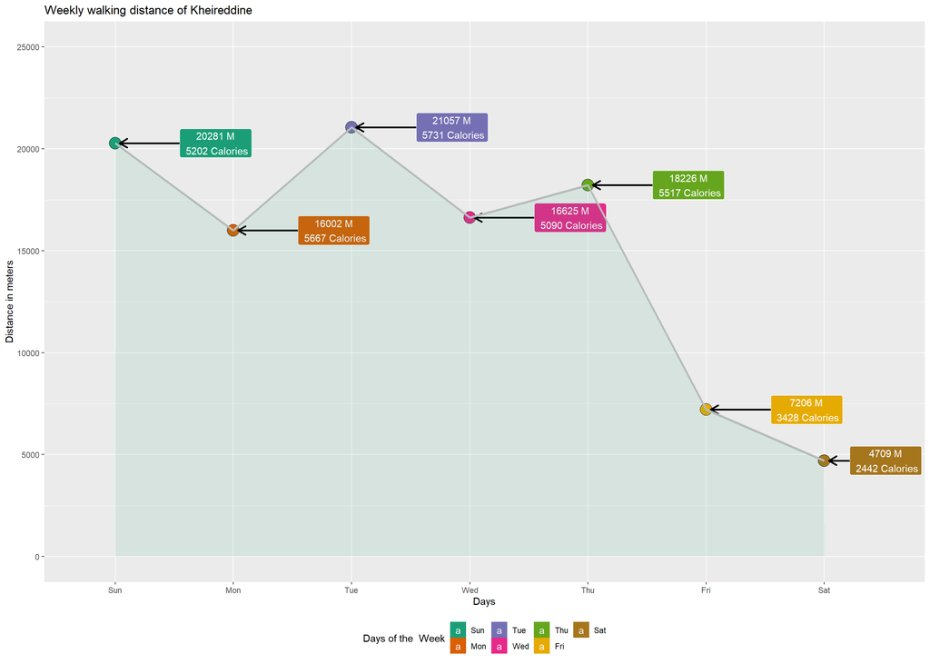

```r
Data_From_GoogleFit_v1_Vis<- ggplot(Data_From_GoogleFit_v1,aes(weekday,Distance..m.,colors=weekday,group=1,label=Distance_label(Distance..m.,Calories..kcal.),fill=weekday))+
  geom_point(shape=21,   size=6) +
  ylim(0,25000)+
  geom_label_repel( color="white",point.padding = 0.50, nudge_x = .85, nudge_y = .15, segment.color="black", segment.size=1,      segment.angle=90, segment.curvature = -1e-20, arrow = arrow(length = unit(0.015, "npc")))+
  geom_line( color="grey",size=1.2) +
  geom_area(alpha=0.1)+
  scale_color_viridis(discrete = TRUE)+
  scale_fill_viridis(discrete = TRUE,option = "C") +
  guides(fill=guide_legend(title="Days of the  Week"))+
  theme(legend.position = "bottom")+
  scale_fill_brewer(palette = "Dark2")+
  labs(title = "Weekly walking distance of Kheireddine",x="Days",y="Distance in meters")

Data_From_GoogleFit_v1_Vis
```

#### After applying my theme

I would like to exhibit the appearance of the graphs after the implementation of my theme.

This R code creates a ggplot graph using the data in the “Data_From_GoogleFit_v1” data frame. I used the “weekday” variable for the x-axis and the “Distance..m.” variable for the y-axis.

- I used the “colors” aesthetic to color the points based on the “weekday” variable, I grouped the data in one group and added a label to the points using the “Distance_label” function with the “Distance..m.” and “Calories..kcal.” variables. It also fills the area under the line graph with the “weekday” variable.

I did that, to effectively display the distance covered and the calories expended, I have chosen to incorporate the calorie data in labels rather than using separate curves. This is because the distance and calorie values have distinct scales, which would make it difficult for the viewer to discern both sets of information if they were presented as separate curves.

- I employed the use of the “geom_point,” “geom_label_repel,” “geom_line,” and “geom_area” functions to create points with a specific shape and size, add labels that repel away from each other, connect the points with a line, and fill the area under the line, respectively.

This was done to guide the viewer’s focus on the progression of the graph, as it can be challenging for the human memory to process data without discernible patterns.

- I utilized the “guides” function to add a title to the fill legend and the “theme” function to position the legend at the bottom of the graph. Additionally, I added a title to the graph and labeled the x and y axes.

This was done to ensure that the graph is easily readable and interpretable, as the graph is relatively large in size. By positioning the legend at the bottom, the width of the graph is aligned with the height, reducing the need for the viewer to move their eyes horizontally to read the legend.

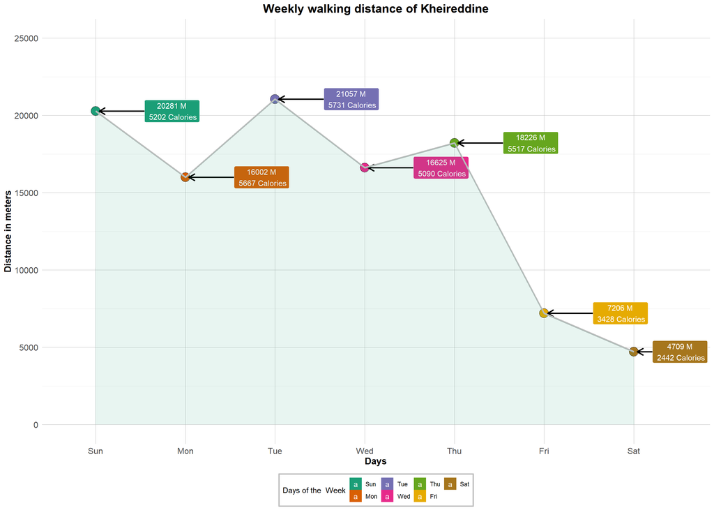

```r
Global_theme(Data_From_GoogleFit_v1_Vis)
```

### Visualization 2 of the Google Fit’s DATA

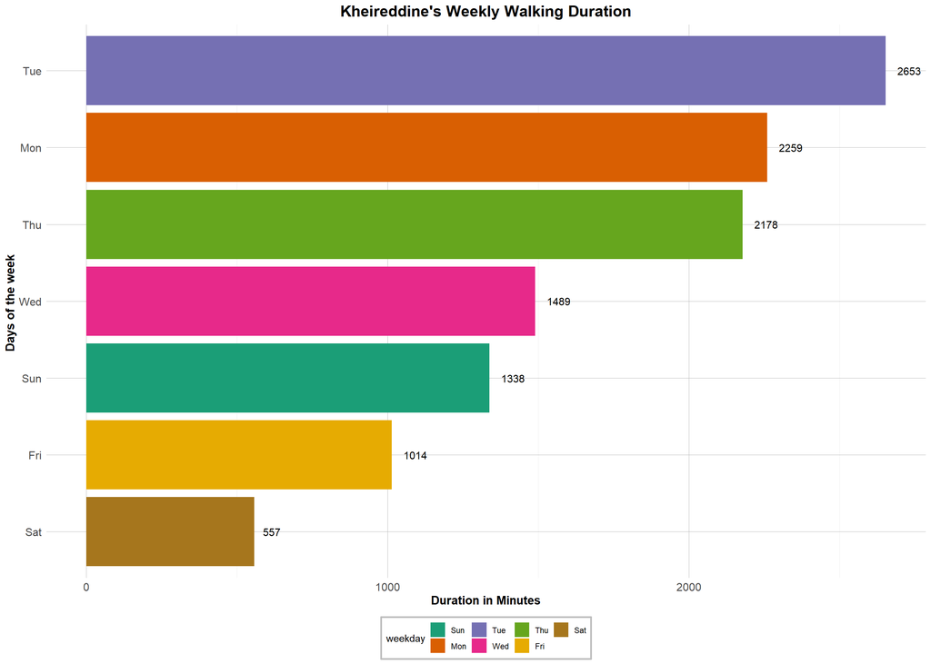

```r
Walking_duration_Vis<-Data_From_GoogleFit %>%
  mutate(weekday= wday(Date,label = TRUE))%>%
  mutate(Walking.duration..ms.= round((Walking.duration..ms./100)/60))%>%
  select(weekday,Walking.duration..ms.) %>% # select the runned Walking duration and the  Day of weeks
  group_by(weekday) %>%
  remove_missing()%>%
  dplyr::summarize(across( .fns=sum))%>% #Sum the value of walking duration  depends on the days of week
  ggplot(aes(x=reorder(weekday,Walking.duration..ms.),y= Walking.duration..ms.,fill=weekday))+geom_col(stat="identity",position='dodge' ,) +coord_flip()+
  theme(legend.position = "bottom")+
  scale_fill_brewer(palette = "Dark2")+
  labs(title = "Kheireddine's Weekly Walking Duration",x="Days of the week ",y="Duration in Minutes")+
  geom_text(aes(label = Walking.duration..ms. ),  colour = "black",  position = position_dodge(width = 1),hjust  = -0.5, size = 4)+  theme_bw()



Global_theme(Walking_duration_Vis)
```

## Browser History Data

I obtained this data from my past research endeavors by utilizing the Google Chrome browser.

*Note:* When requesting data from Google, it returns the browsing history data in JSON format. To facilitate further analysis, I converted the data from JSON to CSV using an online editor.

### Discover the Data

I crafted this code to facilitate the efficient loading and examination of the data contained within the “BrowserHistory.csv” file. It provides a comprehensive overview of the data’s structure, including the names of columns and unique values of a categorical field. This enables me to gain a thorough understanding of the data and determine if further processing or cleaning is required before utilizing it for analysis. Additionally, it also assisted me in verifying the correctness of the data format and the appropriate placement of columns.

```r
Data_from_GoogleBrowser_v1<- read.csv(file="./BrowserHistory.csv")
glimpse(Data_from_GoogleBrowser_v1)  # Get an overview about the Data
```

```
## Rows: 16,441
## Columns: 6
## $ favicon_url     <chr> "https://www.google.com/favicon.ico", "https://www.goo…
## $ page_transition <chr> "LINK", "LINK", "LINK", "LINK", "LINK", "LINK", "LINK"…
## $ title           <chr> "Google Takeout", "Google Takeout", "Google Takeout", …
## $ url             <chr> "https://takeout.google.com/", "https://takeout.google…
## $ client_id       <chr> "pH0xws7eYIZV47Tomtihbg==", "pH0xws7eYIZV47Tomtihbg=="…
## $ time_usec       <dbl> 1.67179e+15, 1.67179e+15, 1.67179e+15, 1.67179e+15, 1.…
```

```r
names(Data_from_GoogleBrowser_v1) # Discover the Name of columns
```

```
## [1] "favicon_url"     "page_transition" "title"           "url"
## [5] "client_id"       "time_usec"
```

```r
unique(Data_from_GoogleBrowser_v1$page_transition) # Discover  Categorical Field
```

```
## [1] "LINK"          "RELOAD"        "TYPED"         "AUTO_TOPLEVEL"
## [5] "GENERATED"     "FORM_SUBMIT"   "AUTO_BOOKMARK"
```

### Transform the data

- **Step 1->** In the initial step of this code, I utilized the mutate() function in conjunction with the sapply() function to generate a new column, “Domain_url,” within the data frame. The strsplit() function was employed to divide the values in the “url” column of the data frame based on the ‘/’ character. The [ operator was then utilized to select the third element of the resulting split string, which corresponds to the domain of the URL.
- **Step 2->** In the subsequent step of the code, I employed the mutate() function along with the if_else() function to verify if the domain begins with “www.” or not. If not, the paste0() function is used to add “www.” to the domain.
- **Step 3->** The third line of the code employs the select() function to preserve solely the “Domain_url” and “page_transition” columns in the data frame. The final line of code utilizes the group_by() function to categorize the data based on the “Domain_url” column.

```r
Data_from_GoogleBrowser_v2<-Data_from_GoogleBrowser_v1 %>%
  mutate(Domain_url= sapply(strsplit(url,"/"), `[`, 3)) %>% # Step 1
  mutate(Domain_url= if_else((substr(Domain_url,1,4)!="www."),paste0("www.",Domain_url),Domain_url)) %>% # Step 2
  select(Domain_url,page_transition) %>% # Step3
  group_by(Domain_url)

Data_from_GoogleBrowser_v2
```

```
## # A tibble: 16,441 × 2
## # Groups:   Domain_url [686]
##    Domain_url             page_transition
##    <chr>                  <chr>
##  1 www.takeout.google.com LINK
##  2 www.takeout.google.com LINK
##  3 www.takeout.google.com LINK
##  4 www.takeout.google.com LINK
##  5 www.takeout.google.com LINK
##  6 www.takeout.google.com LINK
##  7 www.takeout.google.com LINK
##  8 www.takeout.google.com LINK
##  9 www.takeout.google.com LINK
## 10 www.takeout.google.com LINK
## # … with 16,431 more rows
```

### Rediscover the Data and Sumirezed it

In this segment of the code, I chose to re-examine the format of the data to ensure its accuracy before proceeding to summarize it.

- **Step 1->** In this step of the code, I employed the ddply() function from the plyr package to classify the data by the “Domain_url” and “page_transition” columns, and then tallied the number of rows for each group. This generated a summary of the data that includes the number of each type of transition for each domain, as illustrated in the example: {“Google”:{“Linked”:2,“Generated”:5 ….}}
- **Step 2->** In step 2 of the code, I utilized the select() function to retain only the “Domain_url” and “V1” columns, and the group_by() and summarize() functions to group the data by “Domain_url” and calculate the total number of occurrences. This provided a summary of the number of visits for each domain.
- **Step 3->** In step 3 of the code, I utilized the order() function to sort the data by the “V1” column in descending order. This means that the top visited domains will be at the top of the list, making it easier to identify the most frequently visited domains.
- **Step 4->** In step 4, I employed the [ ] operator to select the top 6 rows of the sorted data, this means the top 6 most frequently visited domains will be selected.
- **Step 5->** In step 5 of the code, I utilized the t() function to transpose the matrix, which means reversing the rows and columns of the matrix.

```r
Data_from_GoogleBrowser_v3<-ddply(Data_from_GoogleBrowser_v2,.(Domain_url,page_transition),nrow) # step 1
glimpse(Data_from_GoogleBrowser_v3) # Show data
```

```
## Rows: 1,002
## Columns: 3
## $ Domain_url      <chr> "www.", "www.11percent.de", "www.127.0.0.1:5500", "www…
## $ page_transition <chr> "LINK", "LINK", "AUTO_TOPLEVEL", "LINK", "LINK", "LINK…
## $ V1              <int> 3, 1, 2, 1, 2, 1, 3, 1, 1, 1, 9, 1, 1, 23, 8, 2, 5, 2,…
```

```r
Data_from_GoogleBrowser_v4<-Data_from_GoogleBrowser_v3 %>% # Step 2
  select(Domain_url,V1) %>%
  group_by(Domain_url) %>%
  dplyr::summarize(across( .fns=sum))

Top_visited_Websites=Data_from_GoogleBrowser_v4[order(Data_from_GoogleBrowser_v4$V1,decreasing = TRUE),] #Step 3
Top_visited_Websites= Top_visited_Websites[0:6,1] # Step 4

Top_visited_Websites
```

```
## # A tibble: 6 × 1
##   Domain_url
##   <chr>
## 1 www.google.com
## 2 www.translate.google.com
## 3 www.mail.google.com
## 4 www.newtab
## 5 www.xing.com
## 6 www.service.handyvertrag.de
```

```r
Top_visited_Websites=t(Top_visited_Websites) #Step 5
Top_visited_Websites
```

```
##            [,1]             [,2]                       [,3]
## Domain_url "www.google.com" "www.translate.google.com" "www.mail.google.com"
##            [,4]         [,5]           [,6]
## Domain_url "www.newtab" "www.xing.com" "www.service.handyvertrag.de"
```

### Data selected for use in creating a Radar Chart

- **Step 1->** In step 1, I used the order() function to sort the data by the “Page_transition” field. This ensures that the data is in a specific order, which can make it easier to work with and interpret when creating a radar chart.
- **Step 2->** Filters the data to include only rows where the “Domain_url” field is in a pre-defined list of top visited websites.
- **Step 3->** Replaces any NA values in the dataframe with 0. This will prevent any errors or issues caused by missing data when creating the radar chart
- **Step 4->** Divides the values in each row by the sum of the row. This normalizes the data and ensures that the values are comparable across different rows

```r
  Data_from_GoogleBrowser_v3 =  Data_from_GoogleBrowser_v3[order(Data_from_GoogleBrowser_v3$page_transition,decreasing = TRUE),] # Step1
View(Data_from_GoogleBrowser_v3)

  Radar_Chart_data_v1<- Data_from_GoogleBrowser_v3 %>% #Step 2
  filter( Domain_url %in%  Top_visited_Websites) %>%
  pivot_wider(names_from =page_transition,values_from = V1 )

Radar_Chart_data_v1
```

```
## # A tibble: 6 × 8
##   Domain_url                  TYPED RELOAD  LINK GENER…¹ FORM_…² AUTO_…³ AUTO_…⁴
##   <chr>                       <int>  <int> <int>   <int>   <int>   <int>   <int>
## 1 www.mail.google.com            25     56  1042      NA      NA      NA       2
## 2 www.newtab                    584     23    NA      NA      NA     219      NA
## 3 www.service.handyvertrag.de     1     96   513      NA     175      NA      NA
## 4 www.translate.google.com      118      3  1486      NA      NA      NA      NA
## 5 www.xing.com                   62     31   715      NA      NA      NA      NA
## 6 www.google.com                 NA    155  1029    1488     606       6      NA
## # … with abbreviated variable names ¹GENERATED, ²FORM_SUBMIT, ³AUTO_TOPLEVEL,
## #   ⁴AUTO_BOOKMARK
```

```r
Radar_Chart_data_v1[is.na(Radar_Chart_data_v1)]<-0  #Step 3

Radar_Chart_data_v1
```

```
## # A tibble: 6 × 8
##   Domain_url                  TYPED RELOAD  LINK GENER…¹ FORM_…² AUTO_…³ AUTO_…⁴
##   <chr>                       <int>  <int> <int>   <int>   <int>   <int>   <int>
## 1 www.mail.google.com            25     56  1042       0       0       0       2
## 2 www.newtab                    584     23     0       0       0     219       0
## 3 www.service.handyvertrag.de     1     96   513       0     175       0       0
## 4 www.translate.google.com      118      3  1486       0       0       0       0
## 5 www.xing.com                   62     31   715       0       0       0       0
## 6 www.google.com                  0    155  1029    1488     606       6       0
## # … with abbreviated variable names ¹GENERATED, ²FORM_SUBMIT, ³AUTO_TOPLEVEL,
## #   ⁴AUTO_BOOKMARK
```

```r
Radar_Chart_data_v2<-Radar_Chart_data_v1 %>% #Step 4
  group_by(Domain_url) %>%
  dplyr::summarize(across(AUTO_TOPLEVEL:TYPED ,.fns =~./sum(across(AUTO_TOPLEVEL:TYPED))))


Radar_Chart_data_v2
```

```
## # A tibble: 6 × 7
##   Domain_url                  AUTO_TOPLE…¹ FORM_…² GENER…³  LINK  RELOAD   TYPED
##   <chr>                              <dbl>   <dbl>   <dbl> <dbl>   <dbl>   <dbl>
## 1 www.google.com                   0.00183   0.185   0.453 0.313 0.0472  0
## 2 www.mail.google.com              0         0       0     0.928 0.0499  0.0223
## 3 www.newtab                       0.265     0       0     0     0.0278  0.707
## 4 www.service.handyvertrag.de      0         0.223   0     0.654 0.122   0.00127
## 5 www.translate.google.com         0         0       0     0.925 0.00187 0.0734
## 6 www.xing.com                     0         0       0     0.885 0.0384  0.0767
## # … with abbreviated variable names ¹AUTO_TOPLEVEL, ²FORM_SUBMIT, ³GENERATED
```

### Prepare the Data fo Visualization 1 for Radar Chart and visulize it:

This code uses the “Radar_Chart_data_v2” dataframe to create a radar chart visualization, allowing the viewer to focus on the top six websites that the user accesses most frequently and the methods used to access them. The use of a radar chart is particularly effective in this scenario as it is well-suited for displaying categorical data, making it easier to explore and understand the patterns and relationships within the data.

- *Step 1->* I used the mutate() function and str_remove() function to remove the “www.” prefix from the “Domain_url” field.

This is done to make the chart more readable and consistent.

- **Step 3->** I used the theme() function to customize various elements of the chart such as the strip text and background color, legend position, and plot title font.
  - **The strip.text** option specifies the font size, color and margin of the strip text. This allows for better readability of the chart.
  - **The strip.background** option specifies the background color of the strip, which is “#2C3E50” in this case. This allows to match the color of the chart with the color scheme of the report or presentation.
  - **The legend.position** option specifies the position of the legend, which is “bottom” in this case. This allows to place the legend in a way that it does not overlap with the data points on the chart.
  - **The plot.title** option specifies the font family,face, size and horizontal justification of the plot title. This allows to make the title more visually appealing and easy to read.
- **Step 4->** I utilized the facet_wrap() function to create multiple panels of the chart, organizing the data by domain url and arranging them in a 3x2 grid.

This allows for an easy comparison of the data across multiple websites, and makes the visualization more organized and readable for the viewer.

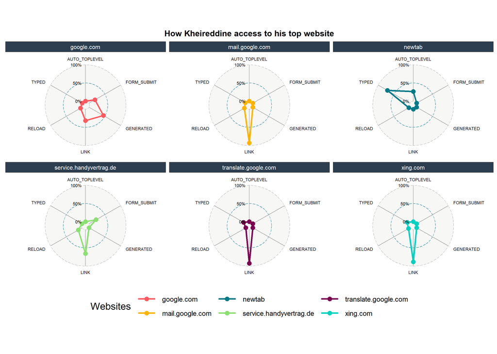

```r
Radar_Chart_data_v2 %>%
  mutate(Domain_url=str_remove(Domain_url,"www.")) %>% #Step1
  ggradar(font.radar = "Circular Air",axis.line.colour = "gray60",legend.title = "Websites",legend.position = "bottom",grid.label.size = 4,axis.label.size=3,group.point.size=4,plot.extent.x.sf=1.2)+ # Step 2


  theme(strip.text = element_text(size = 12,colour = "white",margin= margin(t= 5, b=5)), # Step 3
  strip.background = element_rect(fill = "#2C3E50"),
  legend.position = "bottom",
  plot.title =element_text(hjust = 0.5, family = "Arial",face = "bold",size = 17))+
  labs(title = "How Kheireddine access to his top website")+
  facet_wrap(~Domain_url,ncol=3 )# Step 4
```

### Data visualzation 2 of the Browsing History

I utilized browsing history data to identify the top visited websites by analyzing the number of visits per month, using the month as a categorical variable and the number of visits as a continuous value.

#### Data Mapping

*Step 1->* The first mutate() function uses the sapply() and strsplit() functions to extract the domain url from the url field, and assigns the result to a new field called “Domain_url”.

*Step 2->* The second mutate() function uses the if_else() function to check if the domain url starts with “www.” and if not, it adds “www.” before the domain url.

*Step 3->* The third mutate() function uses the as.POSIXct() and as.numeric() functions to convert the “time_usec” field to a POSIXct date-time format, and assigns the result to a new field called “newdate”.

*Step 4->* The fourth mutate() function uses the as.Date() function to convert the “newdate” field to a date format, and assigns the result to a new field called “newdate2”.

*Step 5->* The fifth mutate() function uses the month() function to extract the month from the “newdate2” field, and assigns the result to a new field called “Month”.

*Step 6->* The select() function is used to select the columns of the dataframe and keep the desired columns.

```r
Data_from_GoogleBrowser_v5<-Data_from_GoogleBrowser_v1 %>%
  mutate(Domain_url= sapply(strsplit(url,"/"), `[`, 3)) %>%  # Step 1
  mutate(Domain_url= if_else((substr(Domain_url,1,4)!="www."),paste0("www.",Domain_url),Domain_url)) %>% # Step 2
  mutate(newdate= as.POSIXct(as.numeric(as.character(time_usec/1000000)), origin="1970-01-01", tz="GMT") ) %>% # Step 3
  mutate(newdate2= as.Date(newdate,format = "%m/%d/%y")) %>% # Step 4
  mutate(Month= month(newdate2,label = TRUE)) %>% # Step 5
  select(newdate2,newdate,Domain_url,Month,time_usec)  # Step 6
```

#### Data Mapping

*Step 1->* The select() function is used to select the columns of the dataframe and keep only the columns “Domain_url” and “Month”.

*Step 2->* The mutate() function is used to add a new column “V1” with the value 1 to the dataframe.

*Step 3->* The group_by() function is used to group the data by the “Domain_url” and “Month” columns.

*Step 4->* The dplyr::summarise_each() function is used to apply the sum function on all columns of the dataframe.

*Step 5->* The dataframe is ordered by the “V1” column in decreasing order.

*Step6 ->* The dataframe is sliced to get the top 10 values of the ‘Domain_url’ column and stored in a new dataframe ‘Data_from_GoogleBrowser_Top_websites’.

```r
  Data_from_GoogleBrowser_v6<-Data_from_GoogleBrowser_v5 %>%
  select(Domain_url,Month) %>% # Step 1
  mutate(V1=1) %>% # Step 2
  group_by(Domain_url,Month) %>% # Step 3
  dplyr::summarise_each( funs(sum)) # Step 4

View(Data_from_GoogleBrowser_v6)



Data_from_GoogleBrowser_v6=Data_from_GoogleBrowser_v6[order(Data_from_GoogleBrowser_v6$V1,decreasing = TRUE),] # Step 5



Data_from_GoogleBrowser_Top_websites=Data_from_GoogleBrowser_v6[0:10 ,1] # Step 6
```

#### Visualize the Data

*Step 1->* The filter() function is used to filter the dataframe to include only rows where the “Domain_url” field is in the pre-defined list of top visited websites( Data_from_GoogleBrowser_Top_websites). # step 6 from the previous code.

*Step2 ->* I used the ggplot() function to initiate the graph, with the “Month” column as the x-axis, the “V1” column as the y-axis, and the “Domain_url” column as the color.

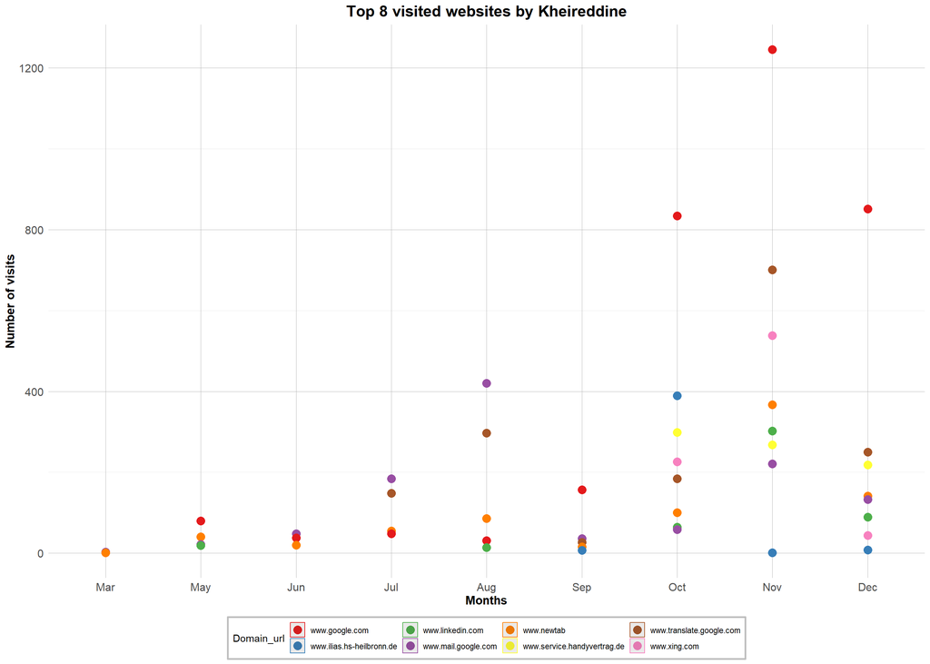

```r
Graph<-Data_from_GoogleBrowser_v6 %>%
  filter(Domain_url %in%  t(Data_from_GoogleBrowser_Top_websites) ) %>% # Step1
  ggplot( aes(x=Month, y=V1,color=Domain_url)) +
  geom_point(size=4) +
  theme_ipsum()+  scale_colour_brewer(palette = "Set1")+
  geom_area(alpha=0.1)+
  theme(legend.position = "bottom")+

  labs(title = "Top 8 visited websites by Kheireddine",x="Months",y="Number of visits")


Global_theme(Graph)
```